# 01: Fundamentos

Presencial

Autor/a

Victor Adrian

Fecha de publicación

2026-03-17

## ¿Cómo pensar programáticamente?

Debemos pensar de manera lógica y programable/estructurada —no necesariamente secuencial— cómo resolver un problema, de manera que tanto una computadora como una persona puedan comprender y abordar los pasos necesarios para su solución.

Esto es:

- Descomponer en partes más pequeñas
- Definir y analizar lo esencial
- Identificar patrones
- Crear un paso a paso ordenado para la solución

Ejemplo: ¿cómo afectó la suba de precio del barril de crudo a la cotización de las empresas energéticas locales?

1. Obtener/descargar datos históricos del precio del barril de Brent en sitios como [Investing](https://www.investing.com/commodities/brent-oil-historical-data), para los últimos dos años.
2. Hacer lo mismo con dos empresas representativas del sector, PAMP e YPFD, de administración privada y público-privada respectivamente, para el mismo periodo.
3. Elaborar índices de igual base para las variables, agrupando a PAMP e YPFD en un mismo índice y establecer un modelo de regresión lineal con el precio del Brent.
4. Graficar los índices y la ecuación lineal.
5. Analizar los desvíos y la robustez del coeficiente de correlación entre las variables.

## Tipos y estructuras de datos

Los tipos más comunes son:

- texto/*string*
- entero/*integer*
- real/*double*
- fecha/*date*
- boolean (verdadero, falso o NA)
- categórico/*categorical* (etiqueta, ej.: alto, medio, bajo)

Y las estructuras (datos agrupados para su organización):

- vector (secuencia ordenada de elementos de igual tipo)
- lista (“bolsa de gato”, puede incluir desde tablas enteras hasta textos)
- tabla/*data frame* (estructura común en ciencia de datos con variables (columnas) y observaciones (filas))
- matriz (tabla numérica sin nombres de columna)

## Variables y asignación

Una variable es la representación de uno o más valores (números, listas, tablas, etc.) tras la asignación de un nombre. También podría decirse que es un nombre que almacena valores en memoria.

Su importancia radica en brindar escalabilidad, trazabilidad y síntesis a la hora de escribir código. Es más fácil recordar un nombre que el o los comandos que lo definen, y lo mismo si se reutiliza más de una vez en la sintaxis de un programa; además de hacer más sencillo llamar/usar a las propiedades del valor que almacena una vez recibe un nombre, dado que actúa como contenedor de un objeto con sus propias características.

En R, las variables son *case sensitive*, es decir, este lenguaje diferencia entre minúsculas y mayúsculas; por lo tanto, `var_1` no es lo mismo que `Var_1`.

Otros tips para nombrar variables *—naming conventions—* en R:

- Usar *snake case* (forma o estilo de combinar palabras consistente en usar solo minúsculas y separar palabras con guión bajo [“_“])
- Usar nombres descriptivos
- Evitar abreviaturas
- Sin espacios, sin mayúsculas
- No empezar con números

Ejemplo: `primera_marca_registrada` es mejor que `1_Marca_Reg` y `marca registrada 1`, que directamente no funcionaría por los espacios.

> **Nota 1:** Para más info ver [convenciones/estilos de nomenclatura](https://www.freecodecamp.org/news/snake-case-vs-camel-case-vs-pascal-case-vs-kebab-case-whats-the-difference/).

## Algoritmos

Los algoritmos son una secuencia o conjunto de **instrucciones finitas, ordenadas y no ambiguas,** cuyo propósito es resolver un problema.

- Finitas: debe tener un comienzo y un final, un número finito de pasos para resolver el problema.
- Ordenadas: un algoritmo debe seguir pasos claros y precisos, enumerados o secuenciados de tal manera que no generen confusión.
- No ambiguas: si yo sigo el algoritmo n veces, debo llegar a la misma solución n veces.

Los pasos para resolver un problema son: 1. Diseño del algoritmo 2. Expresión del algoritmo a un programa 3. Ejecución y validación del programa en una máquina

Todo algoritmo debe describir tres partes: **entrada/*input*, proceso y salida/*output*.**

> **Nota 2:** Definición a partir de [PDF de clase 01](https://github.com/nsidicarocep/curso_cdd_fce_uba_1c2026/blob/main/clases/clase01/Clase_01_slides.pdf) y [video de ProgramacionATS en YouTube](https://youtu.be/V63VmbZcXHM?si=IoOdap22qrmkM5AE).

### Diseño

Involucra la creación del algoritmo, la secuencia de pasos/instrucciones finitas, ordenadas y no ambiguas para resolver un problema. Pero, **¿cómo lo representamos?**

Para representar visualmente un algoritmo existen diversas maneras, siendo las más comunes el diagrama de flujos y el pseudocódigo.

#### Diagrama de flujos

Es la representación gráfica de un algoritmo o proceso, que través de figuras geométricas y flechas expresa visualmente los pasos a seguir y las interrelaciones entre sí. Estas interrelaciones se conocen como **estructuras de control**, están presentes en todas las representaciones de un algoritmo, y permiten controlar su flujo/dirección. Entre ellas tenemos:

- Secuencias (se avanza unívoca y ordenadamente un paso atrás de otro)
- Condicionales (se decide el camino a seguir según se cumplan o no condiciones establecidas)
- Repetitivas (se vuelve uno o más pasos atrás para repetir una o más instrucciones/procesos)

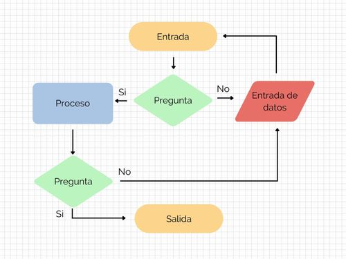

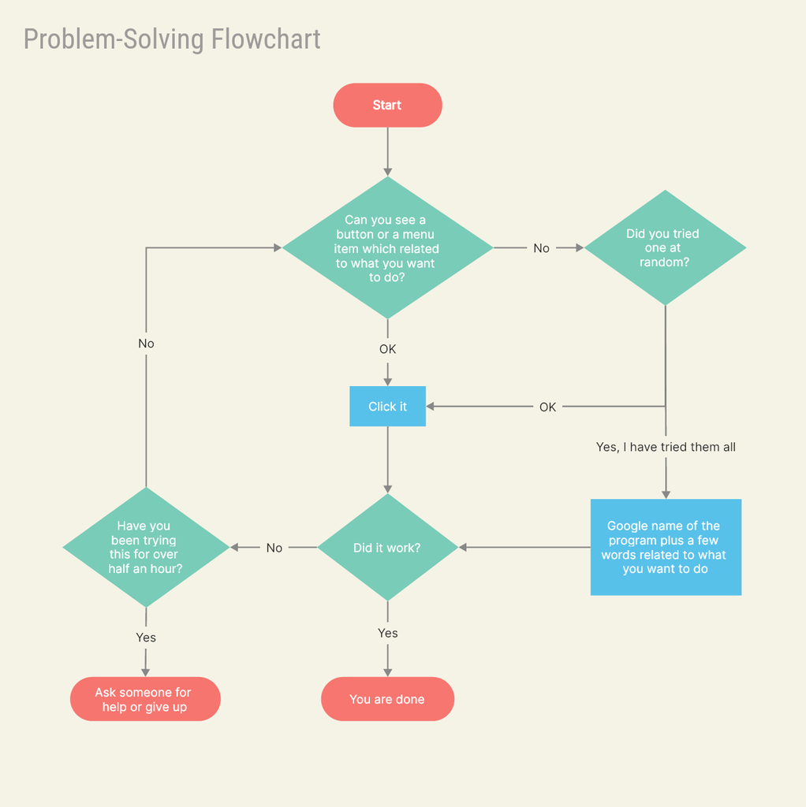